# Create a minimal palette for displaying multiple disease labels

Candace Savonen, Krutika Gaonkar, Jaclyn Taroni, and Stephanie Spielman

2022

## Purpose

There are multiple “disease labels” in the `pbta-histologies.tsv` file, including (from most broad to most narrow) `broad_histology`, `cancer_group`, and `harmonized_diagnosis`. For context, it is helpful to note that an individual `cancer_group` will be nested under a single `broad_histology` and that `cancer_group` is a shorter form of `harmonized_diagnosis` with the following edits:

- Other, Benign tumor and Dysplasia/Gliosis, Dysplasia/Gliosis-Glial-neuronal tumor NOS removed from `cancer_group`
- Neurofibroma/Plexiform;Other updated to Neurofibroma/Plexiform
- Non-germinomatous germ cell tumor;Teratoma updated to Teratoma
- Anaplastic (malignant) meningioma, Meningothelial meningioma and Clear cell meningioma updated to Meningioma
- Embryonal Tumor with Multilayered Rosettes updated to Embryonal tumor with multilayer rosettes

It is often useful to use color to indicate disease label in a plot where multiple groups are visualized when we can not rely particularly heavily on labels (e.g., scatter plots). Unfortunately, there are too many potential labels for us to generate an effective color palette (e.g., of sufficiently distinct colors). In addition, some groupings will contain very few samples.

The purpose of this notebook is to create color palettes for the following:

- `broad_histology` values, where a `broad_histology` contains at least one `cancer_group` with n >= 10
- `cancer_group` values with n >= 10

### Background

You may find [#1174](https://github.com/AlexsLemonade/OpenPBTA-analysis/issues/1174) to be helpful context.

## Usage

This notebook can be run via the command line from the top directory of the repository as follows:

```
Rscript -e "rmarkdown::render('figures/mapping-histology-labels.Rmd',
                              clean = TRUE)"
```

## Set Up

```r
library(tidyverse)
library(RColorBrewer)
```

We should perform some minimal checking to make sure the provided release is *at least* at version 23.

```r
minimum_allowed_release <- 23
release_version <- as.numeric(stringr::str_match(params$release, "-v(\\d+)-")[[2]])
if (release_version < minimum_allowed_release) {
  stop("This notebook should only be used with data release version 23 or above.")
}
```

### Directories and Files

```r
# Path to input directory
input_dir <- file.path("..", "data", params$release)
output_dir <- "palettes"
```

## Read in metadata

Let’s read in the `pbta-histologies.tsv` file.

```r
histologies_df <-
  readr::read_tsv(file.path(input_dir, "pbta-histologies.tsv"), guess_max = 10000)
```

## Identify values to include in palettes

We will use `cancer_group` with n >= 10 to guide what values to include in both our `cancer_group` and `broad_histology` palettes.

```r
included_labels_df <- histologies_df %>%
  # Exclude normal samples
  filter(sample_type == "Tumor") %>%
  # Filter to unique sample--"disease label" pairs
  select(sample_id,
         broad_histology,
         cancer_group) %>%
  distinct() %>%
  # Count samples (e.g., sample_id)
  group_by(broad_histology, cancer_group) %>%
  tally() %>%
  # Add a column called included which is a logical that can be used as
  # a sample size filter & also to drop the NA values
  filter(n >= 10,
         !is.na(cancer_group))

included_labels_df
```

| broad_histology | cancer_group | n |
| --- | --- | --- |
| Benign tumor | Choroid plexus papilloma | 14 |
| Diffuse astrocytic and oligodendroglial tumor | Diffuse intrinsic pontine glioma | 10 |
| Diffuse astrocytic and oligodendroglial tumor | Diffuse midline glioma | 82 |
| Diffuse astrocytic and oligodendroglial tumor | High-grade glioma astrocytoma | 104 |
| Embryonal tumor | Atypical Teratoid Rhabdoid Tumor | 32 |
| Embryonal tumor | CNS Embryonal tumor | 13 |
| Embryonal tumor | Medulloblastoma | 127 |
| Ependymal tumor | Ependymoma | 97 |
| Germ cell tumor | Teratoma | 10 |
| Low-grade astrocytic tumor | Ganglioglioma | 50 |

[output cut: 10 more lines]

### Collapsing “Other” categories

In a later step, we will recode certain cancer groups, e.g., “High-grade glioma astrocytoma” will become “Other high-grade gliomas.” There are other cancer groups that would fit in that category despite not meeting the sample size threshold above. For now, this applies to LGG, HGG, and embryonal tumors.

```r
other_cg_df <- histologies_df %>%
  filter(sample_type == "Tumor",  # Exclude normal samples
         !is.na(cancer_group),
         broad_histology %in% c("Diffuse astrocytic and oligodendroglial tumor",
                                "Low-grade astrocytic tumor",
                                "Embryonal tumor")) %>%
  select(broad_histology,
         cancer_group) %>%
  distinct() %>%
  # Drop everything that meets the sample size requirement above
  anti_join(included_labels_df)
other_cg_df
```

| broad_histology | cancer_group |
| --- | --- |
| Low-grade astrocytic tumor | Gliomatosis cerebri |
| Embryonal tumor | Embryonal tumor with multilayer rosettes |
| Low-grade astrocytic tumor | Diffuse fibrillary astrocytoma |
| Embryonal tumor | Neuroblastoma |
| Embryonal tumor | Ganglioneuroblastoma |
| Embryonal tumor | CNS neuroblastoma |
| Diffuse astrocytic and oligodendroglial tumor | Oligodendroglioma |
| Low-grade astrocytic tumor | Oligodendroglioma |

We’ll create some vectors we’ll use in later steps to group different cancer groups under the same “Other” cancer group display category.

```r
# To become "Other low-grade gliomas"
other_lgg <- c(
  "Low-grade glioma astrocytoma",
  other_cg_df %>%
    filter(broad_histology == "Low-grade astrocytic tumor") %>%
    pull(cancer_group)
)

other_lgg
```

```
[1] "Low-grade glioma astrocytoma"   "Gliomatosis cerebri"
[3] "Diffuse fibrillary astrocytoma" "Oligodendroglioma"
```

```
Low-grade glioma astrocytoma

Gliomatosis cerebri

Diffuse fibrillary astrocytoma

Oligodendroglioma
```

```r
# To become "Other high-grade gliomas"
other_hgg <- c(
  "High-grade glioma astrocytoma",
    other_cg_df %>%
    filter(broad_histology == "Diffuse astrocytic and oligodendroglial tumor") %>%
    pull(cancer_group)
)

other_hgg
```

```
[1] "High-grade glioma astrocytoma" "Oligodendroglioma"
```

```
High-grade glioma astrocytoma

Oligodendroglioma
```

```r
# To become "Other embryonal tumors"
other_embryonal <- c(
  "CNS Embryonal tumor",  # Has n >= 10, but we're trying to limit # of colors
  other_cg_df %>%
  filter(broad_histology == "Embryonal tumor") %>%
  pull(cancer_group)
)

other_embryonal
```

```
[1] "CNS Embryonal tumor"
[2] "Embryonal tumor with multilayer rosettes"
[3] "Neuroblastoma"
[4] "Ganglioneuroblastoma"
[5] "CNS neuroblastoma"
```

```
CNS Embryonal tumor

Embryonal tumor with multilayer rosettes

Neuroblastoma

Ganglioneuroblastoma

CNS neuroblastoma
```

## Create palettes

Outside of this notebook, we’ve done quite a bit of work to identify suitable palettes using http://phrogz.net/css/distinct-colors.html as a reference/starting point. Check out the discussion on [#1174](https://github.com/AlexsLemonade/OpenPBTA-analysis/issues/1174).

### `broad_histology`

We will start by creating a palette for broad histology display values. Broad histology values will be recoded specifically for display in figures in later step.

```r
broad_histology_df <- data.frame(
  broad_histology_display = c("Benign tumor",
                              "High-grade glioma",
                              "Embryonal tumor",
                              # Replace instances of "Ependymal tumor" per reviewer comment
                              # See: https://github.com/AlexsLemonade/OpenPBTA-analysis/issues/1652
                              "Ependymoma",
                              "Germ cell tumor",
                              "Low-grade glioma",
                              "Meningioma",
                              "Mesenchymal non-meningothelial tumor",
                              "Neuronal and mixed neuronal-glial tumor",
                              "Tumor of cranial and paraspinal nerves",
                              "Tumor of sellar region"),
  broad_histology_hex = c("#590024",
                          "#ff80e5",
                          "#220040",
                          "#2200ff",
                          "#0074d9",
                          "#8f8fbf",
                          "#2db398",
                          "#7fbf00",
                          "#685815",
                          "#ffaa00",
                          "#b2502d"),
  stringsAsFactors = FALSE
)

# value for "other" histologies
broad_histology_other_hex <- "#808080"
```

Now to create a legend with `legend()` (h/t [this StackOverflow answer](https://stackoverflow.com/questions/48966645/how-can-i-create-a-legend-without-a-plot-in-r/48966924))

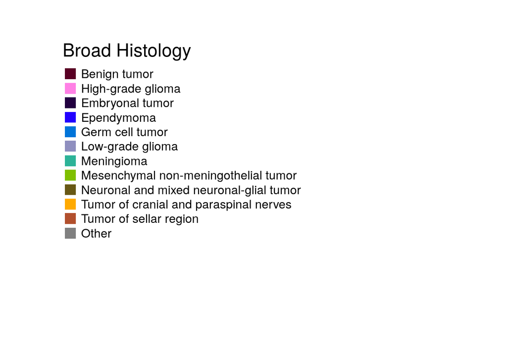

```r
plot(NULL, xaxt = "n", yaxt = "n", bty = "n", ylab = "", xlab = "",
     xlim = 0:1, ylim = 0:1)
legend("topleft",
       legend = c(broad_histology_df$broad_histology_display, "Other"),
       col = c(broad_histology_df$broad_histology_hex,
               broad_histology_other_hex),
       pch = 15, pt.cex = 2, cex = 1, bty = "n")
mtext("Broad Histology", at = 0.135, cex = 1.5)
```

### `cancer_group`

There are 20 `cancer_group` values that we need to account for. These are best used in conjunction with *labels* in figures, but are intended to allow readers to “track” labels *across figures*.

```r
cancer_group_df <- data.frame(
  cancer_group_display = c("Choroid plexus papilloma",
                           "Diffuse intrinsic pontine glioma",
                           "Diffuse midline glioma",
                           "Other high-grade glioma",
                           "Atypical Teratoid Rhabdoid Tumor",
                           "Medulloblastoma",
                           "Other embryonal tumor",
                           "Ependymoma",
                           "Teratoma",
                           "Ganglioglioma",
                           "Pilocytic astrocytoma",
                           "Pleomorphic xanthoastrocytoma",
                           "Subependymal Giant Cell Astrocytoma",
                           "Other low-grade glioma",
                           "Meningioma",
                           "Ewing sarcoma",
                           "Dysembryoplastic neuroepithelial tumor",
                           "Neurofibroma Plexiform",
                           "Schwannoma",
                           "Craniopharyngioma"),
  cancer_group_abbreviation = c("CPP",
                                "DIPG",
                                "DMG",
                                "Other HGG",
                                "ATRT",
                                "MB",
                                "Other ET",
                                "EPN",
                                "Teratoma",
                                "GNG",
                                "PA",
                                "PXA",
                                "SEGA",
                                "Other LGG",
                                "Meningioma",
                                "EWS",
                                "DNET",
                                "PNF",
                                "Schwannoma",
                                "CRANIO"),
  cancer_group_hex = c("#4d2635",
                       "#bf0099",
                       "#ff40d9",
                       "#ffccf5",
                       "#4d0d85",
                       "#a340ff",
                       "#b08ccf",
                       "#2200ff",
                       "#058aff",
                       "#c4c4ff",
                       "#8c8cff",
                       "#4e4ede",
                       "#2828a1",
                       "#000047",
                       "#2db398",
                       "#9fbf60",
                       "#614e01",
                       "#e6ac39",
                       "#ab7200",
                       "#b33000"),
  stringsAsFactors = FALSE
)
# Value for "other" groups
cancer_group_other_hex <- "#b5b5b5"
```

And again, we’ll create a legend with `legend()`

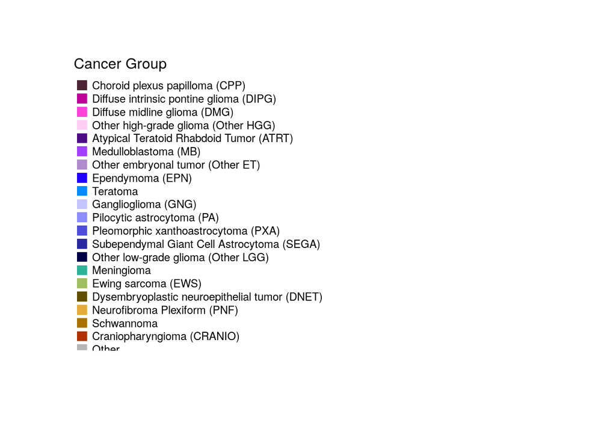

```r
# Combine cancer groups with their abbreviations, WHEN an abbreviation exists for use in legend
legend_names <- cancer_group_df %>%
  mutate(cancer_group_legend = if_else(cancer_group_display == cancer_group_abbreviation,
                                       cancer_group_display,
                                       as.character(glue::glue("{cancer_group_display} ({cancer_group_abbreviation})")))
  ) %>%
  pull(cancer_group_legend)

plot(NULL, xaxt = "n", yaxt = "n", bty = "n", ylab = "", xlab = "",
     xlim = 0:1, ylim = 0:1)
legend("topleft",
       legend = c(legend_names, "Other"),
       col = c(cancer_group_df$cancer_group_hex, cancer_group_other_hex),
       pch = 15, pt.cex = 1.5, cex = 0.75, bty = "n")
mtext("Cancer Group", at = 0.0625, cex = 1)
```

### Output

We can create a data frame that contains both palettes with a series of left joins, where we will then fill the NA values with a single (gray) hex code per column (#808080 for `broad_histology`, #b5b5b5 for `cancer_group`.)

When multiple values are using the same color, it can be helpful to have a separate value for the legend, e.g., for all `#808080` broad histologies, we may want to display `Other`. We’ll add a couple columns for legend-making convenience. We also are recoding some of the disease labels for display per [#1403](https://github.com/AlexsLemonade/OpenPBTA-analysis/issues/1403) and discussion on [#1401](https://github.com/AlexsLemonade/OpenPBTA-analysis/pull/1401).

```r
palette_df <- histologies_df %>%
  # Exclude normal samples
  filter(sample_type == "Tumor") %>%
  # Filter to unique broad histology--cancer group pairs
  select(broad_histology,
         cancer_group) %>%
  distinct() %>%
  # For display specifically, recode broad histology label for LGG, HGG, and EPN
  mutate(broad_histology_display = case_when(
      broad_histology == "Low-grade astrocytic tumor" ~ "Low-grade glioma",
      broad_histology == "Diffuse astrocytic and oligodendroglial tumor" ~ "High-grade glioma",
      broad_histology == "Tumors of sellar region" ~ "Tumor of sellar region",
      broad_histology == "Ependymal tumor" ~ "Ependymoma",  # https://github.com/AlexsLemonade/OpenPBTA-analysis/issues/1652
      TRUE ~ broad_histology
    ),
  # For display, group some cancer groups together into a specific "Other"
  # category
  cancer_group_display = case_when(
    # We must take into account broad histology for (at least) individual
    # Oligodendroglioma samples to get color coded correctly
      (broad_histology == "Diffuse astrocytic and oligodendroglial tumor") & (cancer_group %in% other_hgg) ~ "Other high-grade glioma",
      (broad_histology == "Low-grade astrocytic tumor") & (cancer_group %in% other_lgg) ~ "Other low-grade glioma",
      cancer_group %in% other_embryonal ~ "Other embryonal tumor",
      TRUE ~ cancer_group
    )
  ) %>%
  # Add broad histology palette
  left_join(broad_histology_df, by = "broad_histology_display") %>%
  # Add cancer group palette
  left_join(cancer_group_df, by = "cancer_group_display") %>%
  # Fill all other values with gray colors
  replace_na(list(broad_histology_hex = broad_histology_other_hex,
                  cancer_group_hex = cancer_group_other_hex)) %>%
  # The exception being - if cancer_group == NA, so should cancer_group_hex!
  mutate(cancer_group_hex = if_else(is.na(cancer_group),
                                    NA_character_,
                                    cancer_group_hex)) %>%
  # When a cancer group or broad histology display group does not get its
  # own hex code, we will group those samples into an "Other" category in
  # figures
  mutate(cancer_group_display = if_else(cancer_group_hex == cancer_group_other_hex,
                                        "Other",
                                        cancer_group_display),
         broad_histology_display = if_else(broad_histology_hex == broad_histology_other_hex,
                                           "Other",
                                           broad_histology_display)) %>%
  # Sort by broad_histology for easy browsing
  arrange(broad_histology)
```

And now let’s take a look!

```r
palette_df
```

| broad_histology | cancer_group | broad_histology_display | cancer_group_display | broad_histology_hex | cancer_group_abbreviation | cancer_group_hex |
| --- | --- | --- | --- | --- | --- | --- |
| Benign tumor | NA | Benign tumor | NA | #590024 | NA | NA |
| Benign tumor | Choroid plexus papilloma | Benign tumor | Choroid plexus papilloma | #590024 | CPP | #4d2635 |
| Benign tumor | Atypical choroid plexus papilloma | Benign tumor | Other | #590024 | NA | #b5b5b5 |
| Benign tumor | Adenoma | Benign tumor | Other | #590024 | NA | #b5b5b5 |
| Chordoma | Chordoma | Other | Other | #808080 | NA | #b5b5b5 |
| Choroid plexus tumor | Choroid plexus carcinoma | Other | Other | #808080 | NA | #b5b5b5 |
| Choroid plexus tumor | Choroid plexus cyst | Other | Other | #808080 | NA | #b5b5b5 |
| Diffuse astrocytic and oligodendroglial tumor | High-grade glioma astrocytoma | High-grade glioma | Other high-grade glioma | #ff80e5 | Other HGG | #ffccf5 |
| Diffuse astrocytic and oligodendroglial tumor | Diffuse midline glioma | High-grade glioma | Diffuse midline glioma | #ff80e5 | DMG | #ff40d9 |
| Diffuse astrocytic and oligodendroglial tumor | Diffuse intrinsic pontine glioma | High-grade glioma | Diffuse intrinsic pontine glioma | #ff80e5 | DIPG | #bf0099 |

[output cut: 51 more lines]

### Add `broad_histology_order`

Previously, we had a concept known as `display_order` where we ordered categories based on their number of samples (from large to small). Now that we’ve dropped `display_group`, let’s apply this same concept to `broad_histology`.

```r
broad_histology_order_df <- histologies_df %>%
  # Exclude normal samples
  filter(sample_type == "Tumor",
         # Only count histologies that we'll have a hex code for
         broad_histology %in% included_labels_df$broad_histology) %>%
  # Need to add broad_histology_display here because that's what we need to
  # order/count
  inner_join(select(palette_df,
                    broad_histology,
                    broad_histology_display)) %>%
  # Filter to unique sample--broad_histology_display pairs
  select(sample_id,
         broad_histology_display) %>%
  distinct() %>%
  # Count samples within a broad histology
  count(broad_histology_display) %>%
  # Add Other placeholder
  bind_rows(data.frame(broad_histology_display = "Other",
                       n = 0,
                       stringsAsFactors = FALSE)) %>%
  # Reorder based on sample size except Benign tumor and Other should come last
  # And then add numeric column with the order
  mutate(broad_histology_display = forcats::fct_reorder(broad_histology_display,
                                                        n,
                                                        .desc = TRUE) %>%
           forcats::fct_relevel("Benign tumor",
                                "Other",
                                after = Inf),
         broad_histology_order = as.numeric(broad_histology_display)) %>%
  # No longer require the sample size
  select(-n) %>%
  # Sort for easy browsing
  arrange(broad_histology_display)
broad_histology_order_df
```

| broad_histology_display | broad_histology_order |
| --- | --- |
| Low-grade glioma | 1 |
| High-grade glioma | 2 |
| Embryonal tumor | 3 |
| Ependymoma | 4 |
| Tumor of cranial and paraspinal nerves | 5 |
| Neuronal and mixed neuronal-glial tumor | 6 |
| Tumor of sellar region | 7 |
| Meningioma | 8 |
| Mesenchymal non-meningothelial tumor | 9 |
| Germ cell tumor | 10 |

[output cut: 2 more lines]

And now we’re ready to add this to the palette data frame.

```r
palette_df <- palette_df %>%
  left_join(broad_histology_order_df,
            by = "broad_histology_display")
```

### Add `oncoprint_group` and `oncoprint_main`

For most plots that make use of the `cancer_group` palette, such as a box or violin plot, we will rely heavily on labels and therefore using the gray hex code for multiple groups will not be a problem.

We will have four panels of individual oncoprints, where many `broad_histology` values will get grouped together into the `Other CNS` panel which you can see [here](https://github.com/AlexsLemonade/OpenPBTA-analysis/blob/d31c927a27813ec0b8032fbe768002f31723636f/analyses/oncoprint-landscape/02-plot-oncoprint.R#L181). We can move the information about which cancer groups will be included in each panel into our palette data frame.

```r
# Taken from the current plot oncoprint script as of the writing of this
# See permalink above
other_cns_broad_histologies <- c(
  "Ependymal tumor",
  "Tumors of sellar region",
  "Neuronal and mixed neuronal-glial tumor",
  "Tumor of cranial and paraspinal nerves",
  "Meningioma",
  "Mesenchymal non-meningothelial tumor",
  "Germ cell tumor",
  "Choroid plexus tumor",
  "Histiocytic tumor",
  "Tumor of pineal region",
  "Metastatic tumors",
  "Other astrocytic tumor",
  "Lymphoma",
  "Melanocytic tumor",
  "Other tumor"
)

palette_df <- palette_df %>%
  mutate(oncoprint_group = case_when(
    broad_histology %in% other_cns_broad_histologies ~ "Other CNS",
    broad_histology %in% c(
      "Low-grade astrocytic tumor",
      "Embryonal tumor",
      "Diffuse astrocytic and oligodendroglial tumor"
    ) ~ broad_histology,
    TRUE ~ NA_character_
  ))
```

Now, we need to establish `oncoprint_main`, which is used to delineate whether “Other” cancer groups belong in the main text (`TRUE` value) or in the supplementary information (`FALSE`) oncoprint plots. Groups that belong in the supplement (`oncoprint_main` will be `FALSE`) should be “Other CNS” oncoprint groups that have an “Other” `cancer_group_display` value.

```r
palette_df <- palette_df %>%
  mutate(
    oncoprint_main = case_when(
    oncoprint_group == "Other CNS" & cancer_group_display == "Other" ~ FALSE,
    oncoprint_group == "Other CNS" & cancer_group_display != "Other" ~ TRUE,
    TRUE ~ NA
    )
  )
```

### Display final table and save to TSV

```r
# For browsing
palette_df
```

| broad_histology | cancer_group | broad_histology_display | cancer_group_display | broad_histology_hex | cancer_group_abbreviation | cancer_group_hex | broad_histology_order | oncoprint_group | oncoprint_main |
| --- | --- | --- | --- | --- | --- | --- | --- | --- | --- |
| Benign tumor | NA | Benign tumor | NA | #590024 | NA | NA | 11 | NA | NA |
| Benign tumor | Choroid plexus papilloma | Benign tumor | Choroid plexus papilloma | #590024 | CPP | #4d2635 | 11 | NA | NA |
| Benign tumor | Atypical choroid plexus papilloma | Benign tumor | Other | #590024 | NA | #b5b5b5 | 11 | NA | NA |
| Benign tumor | Adenoma | Benign tumor | Other | #590024 | NA | #b5b5b5 | 11 | NA | NA |
| Chordoma | Chordoma | Other | Other | #808080 | NA | #b5b5b5 | 12 | NA | NA |
| Choroid plexus tumor | Choroid plexus carcinoma | Other | Other | #808080 | NA | #b5b5b5 | 12 | Other CNS | FALSE |
| Choroid plexus tumor | Choroid plexus cyst | Other | Other | #808080 | NA | #b5b5b5 | 12 | Other CNS | FALSE |
| Diffuse astrocytic and oligodendroglial tumor | High-grade glioma astrocytoma | High-grade glioma | Other high-grade glioma | #ff80e5 | Other HGG | #ffccf5 | 2 | Diffuse astrocytic and oligodendroglial tumor | NA |
| Diffuse astrocytic and oligodendroglial tumor | Diffuse midline glioma | High-grade glioma | Diffuse midline glioma | #ff80e5 | DMG | #ff40d9 | 2 | Diffuse astrocytic and oligodendroglial tumor | NA |
| Diffuse astrocytic and oligodendroglial tumor | Diffuse intrinsic pontine glioma | High-grade glioma | Diffuse intrinsic pontine glioma | #ff80e5 | DIPG | #bf0099 | 2 | Diffuse astrocytic and oligodendroglial tumor | NA |

[output cut: 51 more lines]

```r
readr::write_tsv(palette_df,
                 file.path(output_dir,
                           "broad_histology_cancer_group_palette.tsv"))
```